# Topic 11

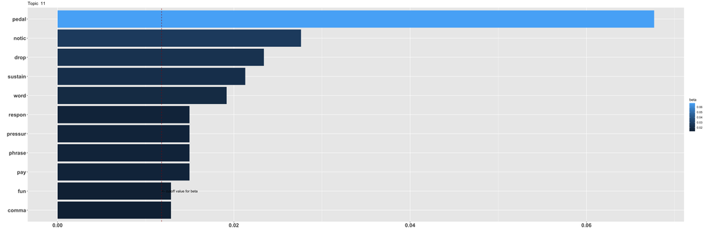

On interpreting beta: the term has a beta probability of being generated from the particular topic.

Values below are gamma : An estimated proportion of words from that document that are generated from that topic.

**Text Record Number: 1013** gamma: 26 % likelihood of this document (based on its words) in this topic

**What helped me figure out how to really use the pedal was to start thinking of elements within phrases like they are written words, as if I’m reading them from a book. The thing about written (and spoken) words is they need a break every once in awhile, a very subtle lull in the timing until the words continue again. In written form, this is represented by a comma. In spoken form, it is literally just a brief rest. I started thinking of the sustain pedal as adding commas to something I am writing. You can think of an entire melody like one long run-on sentence, and like any run-on sentence, it can be formed into a regular sentence by just dropping in some commas. Every time you re-apply the pedal, think of that like adding a comma. You’re creating an intentional break in the resonance to clear a little bit of the air for whatever is coming up next, just like how commas function when interpreting written language or speaking it. So if you’re struggling to figure out how to really use the pedal for something you’re playing, try imagining it like this and think about where you would want to place the “commas”.**

**Text Record Number: 591** gamma: 26 % likelihood of this document (based on its words) in this topic

**If you can hook the digital piano up to a computer through USB, you should be able to open up a DAW software and see exactly what the MIDI inputs are doing. In pretty much any DAW, there should be a configuration menu that allows you to see every single MIDI command being received from the digital piano. This will show pedal activity, as well as keypress activity. With this you should be able to see exactly where the problem lies. As others have said, it could be your pedal. You can troubleshoot this without going and buying another pedal by looking at the MIDI commands. If you notice your DAW is receiving pedal inputs when you aren’t pressing it, then you know that’s the problem. However, if the MIDI data indicates a key is being held down for longer than you’ve actually kept it held down, then it’s a problem with that key. The MIDI data will differentiate between keys being held and the pedal being pressed, as these are actions that send different commands.**

**Text Record Number: 356** gamma: 26 % likelihood of this document (based on its words) in this topic

**Depends on your budget, I have owned entry level digital with non-weight keys, as well as the latest CLP795 Grand.

When I go play test, I look for the feel of the keys, do you like the texture? iI it polished or non-polished? Do you like how heavy or how light the action is? Do you like the sound? I would prepare a lyrical piece and play on it and see if it sounds ok.

I would also play with pedal, does it support half pedalling, progressive pedally? Would also get a digital that supports all 3 pedals instead of just the sustain pedal.

Roland and Yamaha tend to be good quality. I believe Roland is sampled off Steinway or it’s computed live if you buy the 607/609 while Yamaha has their own CFX and Bosendorfer sounds**

**Text Record Number: 1312** gamma: 26 % likelihood of this document (based on its words) in this topic

**So recently, I’ve been getting back into piano after 5 years of not playing. And I noticed that my digital piano sometimes sustains my notes randomly even when I’m not pressing in the damper pedal. When I turn the piano off and on, it goes back to normal, quick notes; But then the notes sustains again later on.

And when I do want to sustain my notes with the damper pedal, they continue to stay sustain when I let go of the pedal. It’s really bugging me

Is there any way to fix this? My digital piano is ~7 years old now and throughout the years, there has been some playing by others that come to visit the house. Or should I invest in a new digital piano? (If it comes to that, I’ll work to regain my skills before buying a new one)

Thanks 🙏**